# The Elston-Stewart Algorithm

Carlos C Vera Recio

- We will compare our results with the implementation on pedprobr and ElstonStewart packages.
- I highly recommend both of these packages instead of writing your implementation from scratch.
  - For example, you can modify the “modele” provided to the Elston() function in the ElstonStewart package to suit your specific case.
  - However, in this R-Markdown we will be writing our functions from “scratch” to learn the algorithm.
  - I’ve learned a lot by looking at objects and functions from both of these packages, and I mimick a lot of their coding practice.

### Load Environment

```r
# clean
rm(list = ls(all=TRUE))

# load
library(pedprobr)
library(ElstonStewart)
```

### Examples of Elston-Stewart Algorithm Implementation of pedprobr

- We will try to make an implementation that produces the same results
- In the example below, the phenotype-genotype penetrance is always 1
- Di-allelic case

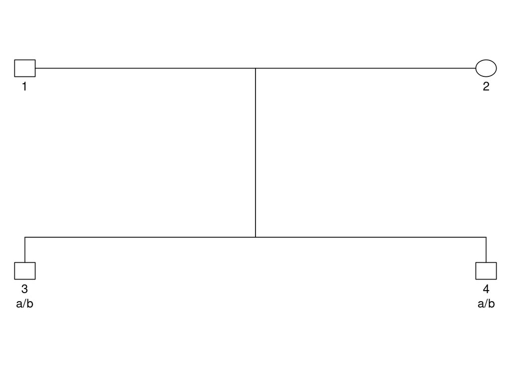

```r
# Pedigree
x = nuclearPed(nch = 2)

# Marker
m = marker(x, geno = c(NA, NA, "a/b", "a/b"), afreq = c(a = 0.2, b = 0.8))

# Plot
plot(x, marker = m)
```

```r
# likelihood
likelihood(x, marker = m)
```

```
## [1] 0.1856
```

### First, we’ll write a function to get founder probabilities

```r
get.founder.probabilities.from.afreq=function(
  g,
  theta
)
{
  if(g == 0)
    {
        return(theta$p^2)
    }
  if(g == 1)
    {
      return(2 * theta$p * (1 - theta$p))
    }
  if(g == 2)
    {
      return((1 - theta$p)^2)
    }
    stop("Unknown Genotype")
}
```

### Make fuction to get the probability of the phenotypes given a genotype

- We call these penetrance
- We will assume all phenotypes have probability 1

```r
get.phenotype.genotype.probabilities=function(
  g,
  pheno
)
{
  return(1)
}
```

### Make function to get transmission probabilities

- These are the probabilities of observing a genotype in the offspring given the genotypes of both parents
- They are derived from Mendel’s rules of inheritance

```r
get.transmission.probabilities=function(
  of,
  fa,
  mo
)
{
    if (fa == 0)
    {
        if (mo == 0 & of == 0)
            return(1)
        if (mo == 1 & (of == 0 | of == 1))
            return(0.5)
        if (mo == 2 & of == 1)
            return(1)
    }
    if (fa == 1)
    {
        if (mo == 0 & (of == 0 | of == 1))
            return(0.5)
        if (mo == 1 & (of == 0 | of == 2))
            return(0.25)
        if (mo == 1 & of == 1)
            return(0.5)
        if (mo == 2 & (of == 1 | of == 2))
            return(0.5)
    }
    if (fa == 2)
    {
        if (mo == 0 & of == 1)
            return(1)
        if (mo == 1 & (of == 1 | of == 2))
            return(0.5)
        if (mo == 2 & of == 2)
            return(1)
    }
    return(0)
}
```

### Make a recursive function to get likelihood of the genotype of an individual given the pedigree structure

```r
# our own implementation of a recursive likelihood function for a given
# individual with genotype g and a pedigree
recursive.likelihood=function(
  id,
  ped.table,
  g,
  genotypes,
  phenotypes,
  theta
)
{
  # get fid and mid
  fid=ped.table$fid[ped.table$id==id]
  mid=ped.table$mid[ped.table$id==id]

  # get index for the id
  index.id = which(ped.table$id==id)

  # get phenotype
  pheno = phenotypes[[index.id]]

  # get founders
  tbl.founders = unique(
    ped.table$id[ped.table$fid == "0" & ped.table$mid == "0"]
  )

  # get likelihood for this genotype if id is founder
  if(fid == "0" & mid == "0")
  {
    genotype.probability = get.founder.probabilities.from.afreq(
      g = g,
      theta = theta
    )
    phenotype.probability = get.phenotype.genotype.probabilities(
      g=g,
      pheno = pheno
    )
    lik = genotype.probability*phenotype.probability
  }else if(fid %in% tbl.founders & mid %in% tbl.founders)
    {
      # get indexes for mo and fa
      fa.index = which(ped.table$id==fid)
      mo.index = which(ped.table$id==mid)

      # get possible parental genotypes and phenotypes
      fa = genotypes[[fa.index]]
      mo = genotypes[[mo.index]]

      # get phenotypes
      fa.pheno = phenotypes[[fa.index]]
      mo.pheno = phenotypes[[mo.index]]

      # get likelihood
      lik.list=c()
      for (i in fa)
      {
        fa.lik=recursive.likelihood(
          g=i,
          id=fid,
          ped.table = ped.table,
          phenotypes =  phenotypes,
          genotypes = genotypes,
          theta = theta
        )
        for (j in mo)
        {
          mo.lik=recursive.likelihood(
            g=j,
            id=mid,
            ped.table = ped.table,
            phenotypes = phenotypes,
            genotypes = genotypes,
            theta = theta
          )
          phenotype.probabilities = get.phenotype.genotype.probabilities(
            g=g,
            pheno = pheno
          )
          genotype.probabilities = get.transmission.probabilities(
            of=g,
            fa=i,
            mo=j
          )
          of.lik=phenotype.probabilities*genotype.probabilities
          curr.lik=of.lik*mo.lik*fa.lik
          lik.list=c(lik.list,curr.lik)
        }
      }
      lik=sum(lik.list)
  }else if( !(fid %in% tbl.founders) | !(mid %in% tbl.founders) )
    {
        # get indexes for mo and fa
        fa.index = which(ped.table$id==fid)
        mo.index = which(ped.table$id==mid)

        # get possible parental genotypes and phenotypes
        fa = genotypes[[fa.index]]
        mo = genotypes[[mo.index]]

        # get phenotypes
        fa.pheno = phenotypes[[fa.index]]
        mo.pheno = phenotypes[[mo.index]]

        lik.list=c()
        for (i in fa)
        {
          fa.lik=recursive.likelihood(
            g=i,
            id=fid,
            ped.table = ped.table,
            phenotypes = phenotypes,
            genotypes = genotypes,
            theta = theta
          )
          for (j in mo)
          {
            mo.lik=recursive.likelihood(
              g=j,
              id=mid,
              ped.table = ped.table,
              phenotypes = phenotypes,
              genotypes = genotypes,
              theta = theta
            )
            phenotype.probabilities = get.phenotype.genotype.probabilities(
              g=g,
              pheno = pheno
            )
            genotype.probabilities = get.transmission.probabilities(
              of=g,
              fa=i,
              mo=j
            )
            of.lik=phenotype.probabilities*genotype.probabilities
            curr.lik=of.lik*mo.lik*fa.lik
            lik.list=c(lik.list,curr.lik)
          }
        }
        lik=sum(lik.list)
  }else
    {
          warning('I dont know what to do')
    }
  return(lik)
}
```

### Make a small pedigree to test our functions on

```r
# Use an easier example pedigree to get the peeling order
mini.conrad = conrad2[c(1:4,6),]
Example.Ped = data.frame(
  id=mini.conrad$id,
  fid=mini.conrad$father,
  mid=mini.conrad$mother,
  sex=mini.conrad$sex
)
Example.Ped[Example.Ped==0]=NA
Example.Ped = as.ped(Example.Ped)

# make some input data four our function practice
ped.table = as.data.frame(Example.Ped)
ped.table$id[ped.table$id==6]='5'

# get genotypes
genotypes <- c(
  rep(
    list(0:2),
    5
  )
)

genotypes[[1]]=2
genotypes[[5]]=2
# get phenotypes
phenotypes=c(
  rep(
    list(
      c(0, 65)
    ), 5
  )
)
phenotypes[[5]]=c(1,35)

# make theta
theta=list(p=0.2)
```

### Lets use the pedtools R-Package to know what the answer should be

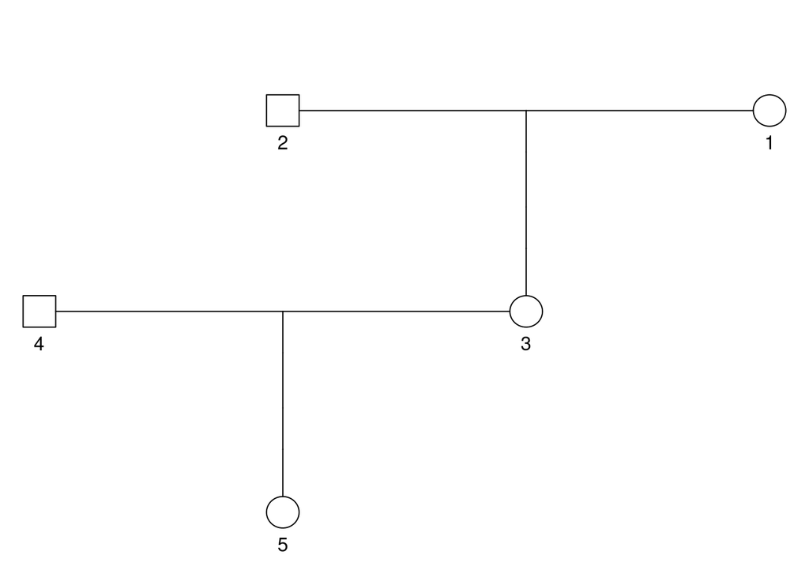

```r
# individual 3 has genotype=2
ped5=as.ped(ped.table)

# look at ped
plot(ped5)
```

```r
# get likelihood using pedprobr
pedtools.lik = likelihood(
  x=ped5,
  marker = marker(
    x = ped5,
    geno = c("b/b",NA,NA,NA,"b/b"),
    afreq = c(a=0.2, b=0.8)
  )
)
pedtools.lik
```

```
## [1] 0.4608
```

### Lets use our implementation to see if we get the same result as pedtools

```r
# example function of full pedigree likelihood function
our.lik =  recursive.likelihood(
  id = 5,
  g = 2,
  ped.table=ped.table,
  genotypes=genotypes,
  phenotypes=phenotypes,
  theta = theta
)
our.lik
```

```
## [1] 0.4608
```

#### Another example using the ElstonStewart and pedprobr R-Packages

- We will use the Conrad data
- This family has many generation, inbreeding and loops
  - The Elston-Stewart algorithm does not work well in pedigrees with loops/inbreeding
  - One possibility is to cut the pedigree to remove loops and inbreeding. I have not implemented this in our function and thus will not be testing it in this family.
  - Packages like the ElstonStewart or pedprobr/pedtools R-Package can deal with such complex pedigrees

```r
## cf Elston-Stewart vignette for more comments on this example
data(conrad2)

# creating an es.pedigree object
conrad.genotypes <- c(
  rep(
    list(
      0:2
    ), 22
  )
)
conrad.genotypes[[1]]=2
conrad.genotypes[[22]]=2

# get phenotypes
conrad.phenotypes=c(
  rep(
    list(
      c(0, 65)
    ), 22
  )
)
conrad.phenotypes[[22]]=c(1,35)

# make es.pedigree object for Elston-Stewart
X <- es.pedigree(
  id = conrad2$id,
  father = conrad2$father,
  mother = conrad2$mother,
  sex = conrad2$sex,
  pheno = conrad.phenotypes,
  geno = conrad.genotypes
)

# running Elston-Stewart
r <- Elston(
  ped = X,
  modele = modele.di,
  theta = theta
)
r$result
```

```
## [1] 0.4206125
```

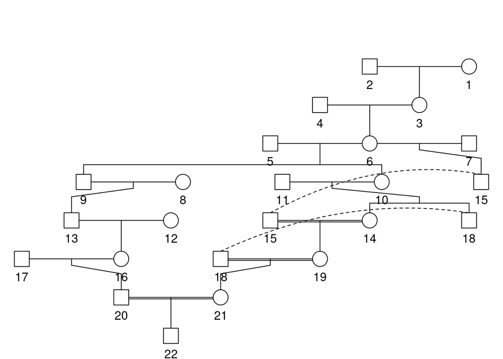

```r
# Use the conrad data set to get big ped
Big.Ped = data.frame(
  id=conrad2$id,
  fid=conrad2$father,
  mid=conrad2$mother,
  sex=conrad2$sex
)
Big.Ped[Big.Ped==0]=NA
Big.Ped = as.ped(Big.Ped)

# look at ped
plot(Big.Ped)
```

```r
# calculating likelihood of big conrad ped using pedtools
likelihood(
  x=Big.Ped,
  markers = marker(
    x=Big.Ped,
    geno = c('b/b',rep(NA, 20), 'b/b'),
    afreq = c(a=0.2, b=0.8)
  )
)
```

```
## [1] 0.4206125
```

- Loops, inbreeding, and long pedigrees increase the complexity of the algorithm and may also cause errors in the estimation. As I said, I will not be trying our implementation for pedigrees with loops.
- The ElstonStewart and pedprobr/pedtools were fast and robust for this case.
- This goes to show that our simple implementation still has a lot to improve! This example is meant to show pedigree structure that is unfit for the Elston-Stewart algorithm.

### Use a subset of individuals from the conrad pedigree to get mid-size complex pedigree

- Get another complex pedigree without inbreeding or loops
- We will again test our implementation and compare with pedprobr

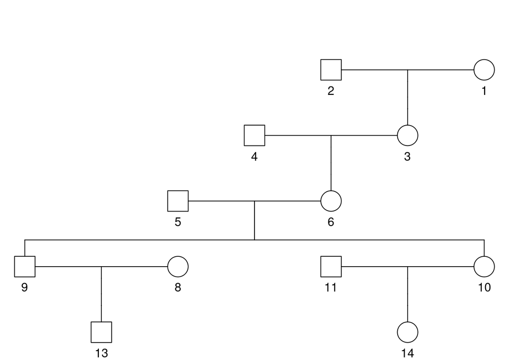

```r
# Use the conrad data set to get big ped
Mid.Ped = data.frame(
  id=conrad2$id,
  fid=conrad2$father,
  mid=conrad2$mother,
  sex=conrad2$sex
)
Mid.Ped[Mid.Ped==0]=NA
Mid.Ped = Mid.Ped[c(1:6, 8:11, 13:14),]
Mid.Ped = as.ped(Mid.Ped)

# make individual 14 have genotype = 1
conrad.genotypes[[1]]=c(0,1,2)
conrad.genotypes[[14]]=1
conrad.genotypes[[2]]=2

# look at ped
plot(Mid.Ped)
```

```r
# calculating likelihood of Mid Ped using pedtools
likelihood(
  x=Mid.Ped,
  markers = marker(
    x=Mid.Ped,
    geno = c(NA, "b/b", rep(NA, 9), 'a/b'),
    afreq = c(a=0.2, b=0.8)
  )
)
```

```
## [1] 0.1952
```

```r
# Use our implementation to get Mid size pedigree likelihood
our.mid.ped.lik = recursive.likelihood(
  ped.table=as.data.frame(Mid.Ped),
  g=1,
  id=14,
  genotypes=conrad.genotypes[c(1:6, 8:11, 13:14)],
  phenotypes=conrad.phenotypes[c(1:6, 8:11, 13:14)],
  theta = theta
)
our.mid.ped.lik
```

```
## [1] 0.1952
```

- In this complex pedigree without inbreeding or loops we can see that our algorithm works very well!

### Summary of what we learned

- The Elston-Stewart algorithm can calculate the likelihood of family data even in complex pedigrees.
- It is ideal on pedigrees that do not have loops/inbreeding.
- The algorithm needs as input:
  - allele frequency (to calculate founder genotype probabilities)
  - Mendelian rules of transmission (to get transmission probabilities)
  - Penetrance estimate/ penetrance function (to calculate phenotype probabilities give genotypes)
- On our examples, we implemented an instance of the Elston-Stewart Algorithm for the di-allelic case where phenotype probabilities are always 1.
  - The phenotype probabilities need not be 1 in every case. This can be easily adjusted by changing the phenotype probability function.
  - For example, a phenotype based on observing a particular event by age t, that can be modeled using a parametric survival analysis (for example, an exponential function), non-parametric (Kaplan-Meier estimator) or semi-parametric (Cox Proportional Hazards framework)